# Plants Seedling Classification

## Model Building - Convolutional Neural Network (CNN)

## Model-1

Let's create a CNN model sequentially, where we will be adding the layers one after another.

First, we need to clear the previous model's history from the session.

In Keras, we need a special command to clear the model's history, otherwise the previous model history remains in the backend.

Also, let's fix the seed again after clearing the backend.

Let's set the seed for random number generators in Numpy, the Random library in Python, and in TensorFlow to be able to reproduce the same results every time we run the code.

```python
# Clearing backend
from tensorflow.keras import backend
backend.clear_session()
```

```python
# Fixing the seed for random number generators
import random
np.random.seed(42)
random.seed(42)
tf.random.set_seed(42)
```

Now, let's build a CNN Model with the following 2 main parts -

1. The Feature Extraction layers which are comprised of convolutional and pooling layers.
2. The Fully Connected classification layers for prediction.

```python
# Intializing a sequential model
model = Sequential()

# Adding first conv layer with 64 filters and kernel size 3x3 , padding 'same' provides the output size same as the input size
# Input_shape denotes input image dimension of images
model.add(Conv2D(64, (3, 3), activation='relu', padding="same", input_shape=(64, 64, 3)))

# Adding max pooling to reduce the size of output of first conv layer
model.add(MaxPooling2D((2, 2), padding = 'same'))

model.add(Conv2D(32, (3, 3), activation='relu', padding="same"))
model.add(MaxPooling2D((2, 2), padding = 'same'))

# flattening the output of the conv layer after max pooling to make it ready for creating dense connections
model.add(Flatten())

# Adding a fully connected dense layer with 100 neurons
model.add(Dense(16, activation='relu'))
model.add(Dropout(0.3))
# Adding the output layer with 10 neurons and activation functions as softmax since this is a multi-class classification problem
model.add(Dense(12, activation='softmax'))

# Using SGD Optimizer
# opt = SGD(learning_rate=0.01, momentum=0.9)
opt=Adam()
# Compile model
model.compile(optimizer=opt, loss='categorical_crossentropy', metrics=['accuracy'])

# Generating the summary of the model
model.summary()
```

```
Model: "sequential"
_________________________________________________________________
 Layer (type)                Output Shape              Param #
=================================================================
 conv2d (Conv2D)             (None, 64, 64, 64)        1792

 max_pooling2d (MaxPooling2D  (None, 32, 32, 64)       0
 )

 conv2d_1 (Conv2D)           (None, 32, 32, 32)        18464

 max_pooling2d_1 (MaxPooling  (None, 16, 16, 32)       0
 2D)

 flatten (Flatten)           (None, 8192)              0

 dense (Dense)               (None, 16)                131088

 dropout (Dropout)           (None, 16)                0

 dense_1 (Dense)             (None, 12)                204

=================================================================
Total params: 151,548
Trainable params: 151,548
Non-trainable params: 0
_________________________________________________________________
```

## Fitting the model on the train data

```python
history_1 = model.fit(
            X_train_normalized, y_train_encoded,
            epochs=30,
            validation_split=0.1,
            # shuffle=True,
            batch_size=32,
            verbose=2
)
```

```
121/121 - 31s - loss: 2.4027 - accuracy: 0.1510 - val_loss: 2.1484 - val_accuracy: 0.2897 - 31s/epoch - 257ms/step
121/121 - 30s - loss: 2.1241 - accuracy: 0.2872 - val_loss: 1.9012 - val_accuracy: 0.4019 - 30s/epoch - 246ms/step
121/121 - 31s - loss: 1.9969 - accuracy: 0.3119 - val_loss: 1.7580 - val_accuracy: 0.4252 - 31s/epoch - 257ms/step
121/121 - 31s - loss: 1.9165 - accuracy: 0.3125 - val_loss: 1.7044 - val_accuracy: 0.4206 - 31s/epoch - 256ms/step
121/121 - 30s - loss: 1.8505 - accuracy: 0.3392 - val_loss: 1.6272 - val_accuracy: 0.5047 - 30s/epoch - 245ms/step
121/121 - 30s - loss: 1.7547 - accuracy: 0.3548 - val_loss: 1.5318 - val_accuracy: 0.4883 - 30s/epoch - 246ms/step
121/121 - 31s - loss: 1.7072 - accuracy: 0.3707 - val_loss: 1.5327 - val_accuracy: 0.4836 - 31s/epoch - 252ms/step
121/121 - 30s - loss: 1.6472 - accuracy: 0.3897 - val_loss: 1.3661 - val_accuracy: 0.5584 - 30s/epoch - 247ms/step
121/121 - 30s - loss: 1.6056 - accuracy: 0.4079 - val_loss: 1.3708 - val_accuracy: 0.5584 - 30s/epoch - 246ms/step
121/121 - 30s - loss: 1.5765 - accuracy: 0.4162 - val_loss: 1.3500 - val_accuracy: 0.5724 - 30s/epoch - 245ms/step
121/121 - 29s - loss: 1.5711 - accuracy: 0.4195 - val_loss: 1.3185 - val_accuracy: 0.5654 - 29s/epoch - 242ms/step
121/121 - 46s - loss: 1.5494 - accuracy: 0.4297 - val_loss: 1.3350 - val_accuracy: 0.5397 - 46s/epoch - 377ms/step
121/121 - 30s - loss: 1.5422 - accuracy: 0.4328 - val_loss: 1.2813 - val_accuracy: 0.5701 - 30s/epoch - 246ms/step
121/121 - 30s - loss: 1.4973 - accuracy: 0.4502 - val_loss: 1.2535 - val_accuracy: 0.5888 - 30s/epoch - 251ms/step
121/121 - 42s - loss: 1.5035 - accuracy: 0.4554 - val_loss: 1.3042 - val_accuracy: 0.5818 - 42s/epoch - 346ms/step
121/121 - 41s - loss: 1.4722 - accuracy: 0.4656 - val_loss: 1.2841 - val_accuracy: 0.5724 - 41s/epoch - 335ms/step
121/121 - 40s - loss: 1.4818 - accuracy: 0.4497 - val_loss: 1.3108 - val_accuracy: 0.5794 - 40s/epoch - 329ms/step
121/121 - 46s - loss: 1.4511 - accuracy: 0.4635 - val_loss: 1.2186 - val_accuracy: 0.5818 - 46s/epoch - 376ms/step
121/121 - 35s - loss: 1.4495 - accuracy: 0.4682 - val_loss: 1.2460 - val_accuracy: 0.5794 - 35s/epoch - 291ms/step
121/121 - 29s - loss: 1.4464 - accuracy: 0.4718 - val_loss: 1.2084 - val_accuracy: 0.5841 - 29s/epoch - 243ms/step
121/121 - 30s - loss: 1.4095 - accuracy: 0.4814 - val_loss: 1.2131 - val_accuracy: 0.6098 - 30s/epoch - 248ms/step
121/121 - 32s - loss: 1.3786 - accuracy: 0.4916 - val_loss: 1.1814 - val_accuracy: 0.6051 - 32s/epoch - 261ms/step
121/121 - 42s - loss: 1.3832 - accuracy: 0.4770 - val_loss: 1.1808 - val_accuracy: 0.6145 - 42s/epoch - 351ms/step
121/121 - 30s - loss: 1.3375 - accuracy: 0.4936 - val_loss: 1.1473 - val_accuracy: 0.6192 - 30s/epoch - 247ms/step
121/121 - 29s - loss: 1.3480 - accuracy: 0.4975 - val_loss: 1.1397 - val_accuracy: 0.6262 - 29s/epoch - 243ms/step
121/121 - 40s - loss: 1.3257 - accuracy: 0.5043 - val_loss: 1.1807 - val_accuracy: 0.6215 - 40s/epoch - 328ms/step
121/121 - 45s - loss: 1.3051 - accuracy: 0.5100 - val_loss: 1.1523 - val_accuracy: 0.6028 - 45s/epoch - 370ms/step
121/121 - 50s - loss: 1.2849 - accuracy: 0.5188 - val_loss: 1.1437 - val_accuracy: 0.6215 - 50s/epoch - 414ms/step
121/121 - 31s - loss: 1.2587 - accuracy: 0.5160 - val_loss: 1.1194 - val_accuracy: 0.6332 - 31s/epoch - 258ms/step
121/121 - 29s - loss: 1.2628 - accuracy: 0.5178 - val_loss: 1.1193 - val_accuracy: 0.6332 - 29s/epoch - 244ms/step
```

## Model Evaluation

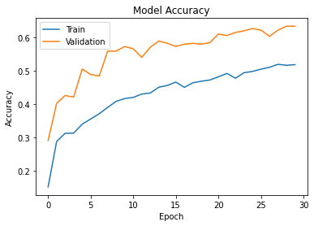

```python
plt.plot(history_1.history['accuracy'])
plt.plot(history_1.history['val_accuracy'])
plt.title('Model Accuracy')
plt.ylabel('Accuracy')
plt.xlabel('Epoch')
plt.legend(['Train', 'Validation'], loc='upper left')
plt.show()
```

*Observations:*

## Evaluating the model on test data

```python
accuracy = model.evaluate(X_test_normalized, y_test_encoded, verbose=2)
```

```
15/15 - 1s - loss: 1.1736 - accuracy: 0.6316 - 945ms/epoch - 63ms/step
```

## Generating the predictions using test data

```python
# Here we would get the output as probablities for each category
y_pred=model.predict(X_test_normalized)
```

```python
y_pred
```

```
array([[1.09874218e-05, 1.22168786e-11, 6.73649980e-09, ...,
        5.27223758e-03, 4.38157399e-10, 2.48443172e-03],
       [1.66020725e-10, 8.90419334e-02, 2.86280550e-02, ...,
        6.74159452e-02, 6.81265354e-01, 5.55500947e-02],
       [5.89081765e-07, 1.45122074e-02, 4.66782972e-03, ...,
        1.07032210e-01, 6.92848265e-01, 3.05882618e-02],
       ...,
       [2.64065087e-01, 6.51067609e-08, 1.75980938e-04, ...,
        2.15251230e-08, 1.17872323e-09, 4.60183388e-03],
       [7.57237967e-06, 1.02935161e-03, 6.18628040e-02, ...,
        1.31721675e-01, 6.78519078e-04, 2.02117022e-02],
       [5.73528450e-06, 8.67484361e-02, 2.93071494e-02, ...,
        2.69943655e-01, 3.81976753e-01, 4.00505774e-02]], dtype=float32)
```

## Plotting the Confusion Matrix

- The Confusion matrix is also defined as an inbuilt function in the TensorFlow module, so we can use that for evaluating the classification model.
- The Confusion matrix expects categorical data as input. However, y_test_encoded is an encoded value, whereas y_pred has probabilities. So,we must retrieve the categorical values from the encoded values.
- We will use the argmax() function to obtain the maximum value over each category on both y_test_encoded and y_pred and obtain their respective classes.

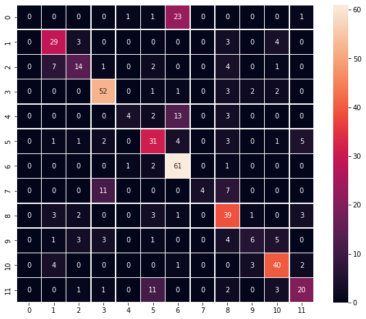

```python
# Obtaining the categorical values from y_test_encoded and y_pred
y_pred_arg=np.argmax(y_pred,axis=1)
y_test_arg=np.argmax(y_test_encoded,axis=1)

# Plotting the Confusion Matrix using confusion matrix() function which is also predefined tensorflow module
confusion_matrix = tf.math.confusion_matrix(y_test_arg,y_pred_arg)
f, ax = plt.subplots(figsize=(10, 8))
sns.heatmap(
    confusion_matrix,
    annot=True,
    linewidths=.4,
    fmt="d",
    square=True,
    ax=ax
)
plt.show()
```

## Data Augmentation

In most of the real-world case studies, it is challenging to acquire a large number of images and then train CNNs. To overcome this problem, one approach we might consider is Data Augmentation. CNNs have the property of translational invariance, which means they can recognise an object even if its appearance shifts translationally in some way. Taking this attribute into account, we can augment the images using the techniques listed below -

1. Horizontal Flip (should be set to True/False)
2. Vertical Flip (should be set to True/False)
3. Height Shift (should be between 0 and 1)
4. Width Shift (should be between 0 and 1)
5. Rotation (should be between 0 and 180)
6. Shear (should be between 0 and 1)
7. Zoom (should be between 0 and 1) etc.

```python
# Clearing backend
from tensorflow.keras import backend
backend.clear_session()

# Fixing the seed for random number generators
import random
np.random.seed(42)
random.seed(42)
tf.random.set_seed(42)
```

```python
# All images to be rescaled by 1/255.
train_datagen = ImageDataGenerator(
                              rotation_range=20,
                              fill_mode='nearest'
                              )
# test_datagen  = ImageDataGenerator(rescale = 1.0/255.)
```

```python
# Intializing a sequential model
model = Sequential()

# Adding first conv layer with 64 filters and kernel size 3x3 , padding 'same' provides the output size same as the input size
# Input_shape denotes input image dimension images
model.add(Conv2D(64, (3, 3), activation='relu', padding="same", input_shape=(64, 64, 3)))

# Adding max pooling to reduce the size of output of first conv layer
model.add(MaxPooling2D((2, 2), padding = 'same'))
# model.add(BatchNormalization())
model.add(Conv2D(32, (3, 3), activation='relu', padding="same"))
model.add(MaxPooling2D((2, 2), padding = 'same'))
model.add(BatchNormalization())
# flattening the output of the conv layer after max pooling to make it ready for creating dense connections
model.add(Flatten())

# Adding a fully connected dense layer with 100 neurons
model.add(Dense(16, activation='relu'))
model.add(Dropout(0.3))
# Adding the output layer with 12 neurons and activation functions as softmax since this is a multi-class classification problem
model.add(Dense(12, activation='softmax'))

# Using SGD Optimizer
# opt = SGD(learning_rate=0.01, momentum=0.9)
opt=Adam()
# Compile model
model.compile(optimizer=opt, loss='categorical_crossentropy', metrics=['accuracy'])

# Generating the summary of the model
model.summary()
```

```
Model: "sequential"
_________________________________________________________________
 Layer (type)                Output Shape              Param #
=================================================================
 conv2d (Conv2D)             (None, 64, 64, 64)        1792

 max_pooling2d (MaxPooling2D  (None, 32, 32, 64)       0
 )

 conv2d_1 (Conv2D)           (None, 32, 32, 32)        18464

 max_pooling2d_1 (MaxPooling  (None, 16, 16, 32)       0
 2D)

 batch_normalization (BatchN  (None, 16, 16, 32)       128
 ormalization)

 flatten (Flatten)           (None, 8192)              0

 dense (Dense)               (None, 16)                131088

 dropout (Dropout)           (None, 16)                0

 dense_1 (Dense)             (None, 12)                204

=================================================================
Total params: 151,676
Trainable params: 151,612
Non-trainable params: 64
_________________________________________________________________
```

```python
# Epochs
epochs = 25
# Batch size
batch_size = 64

history = model.fit(train_datagen.flow(X_train_normalized,y_train_encoded,
                                       batch_size=batch_size,
                                       seed=42,
                                       shuffle=False),
                    epochs=epochs,
                    steps_per_epoch=X_train_normalized.shape[0] // batch_size,
                    validation_data=(X_test_normalized,y_test_encoded),
                    verbose=1)
```

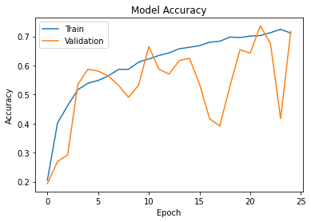

```python
plt.plot(history.history['accuracy'])
plt.plot(history.history['val_accuracy'])
plt.title('Model Accuracy')
plt.ylabel('Accuracy')
plt.xlabel('Epoch')
plt.legend(['Train', 'Validation'], loc='upper left')
plt.show()
```

```python
accuracy = model.evaluate(X_test_normalized, y_test_encoded, verbose=2)
```

```
15/15 - 1s - loss: 0.8836 - accuracy: 0.7179 - 976ms/epoch - 65ms/step
```

*Observations:*

- We can observe that our accuracy has improved compared to our previous model.

```python
# Here we would get the output as probablities for each category
y_pred=model.predict(X_test_normalized)
```

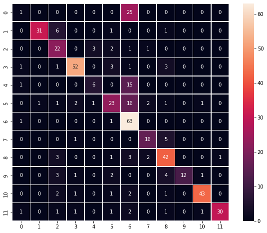

```python
# Obtaining the categorical values from y_test_encoded and y_pred
y_pred_arg=np.argmax(y_pred,axis=1)
y_test_arg=np.argmax(y_test_encoded,axis=1)

# Plotting the Confusion Matrix using confusion matrix() function which is also predefined tensorflow module
confusion_matrix = tf.math.confusion_matrix(y_test_arg,y_pred_arg)
f, ax = plt.subplots(figsize=(10, 8))
sns.heatmap(
    confusion_matrix,
    annot=True,
    linewidths=.4,
    fmt="d",
    square=True,
    ax=ax
)
plt.show()
```

- We can observe that this model has outperformed our previous model.
- Let's try data augmentation model with different parameters.

## Model-3 with Data Augmentation (Different parameters)

Trying to create a new model with different set of parameters and image size

```python
#Resizing image to 256
images_resized=[]
height = 256
width = 256
dimensions = (width, height)
for i in range(len(images)):
  images_resized.append( cv2.resize(images[i], dimensions, interpolation=cv2.INTER_LINEAR))


# Applying Gaussian Blur to denoise the images
images_gb=[]
for i in range(len(images)):
  # gb[i] = cv2.cvtColor(images[i], cv2.COLOR_BGR2RGB)
  images_gb.append(cv2.GaussianBlur(images[i], ksize =(3,3),sigmaX =  0))

# Splitting
from sklearn.model_selection import train_test_split
X_train, X_test, y_train, y_test = train_test_split(np.array(images_resized),labels , test_size=0.1, random_state=42,stratify=labels)

# Convert labels from names to one hot vectors.
# We have already used encoding methods like onehotencoder and labelencoder earlier so now we will be using a new encoding method called labelBinarizer.
# Labelbinarizer works similar to onehotencoder
from sklearn.preprocessing import LabelBinarizer
enc = LabelBinarizer()
y_train_encoded = enc.fit_transform(y_train)
y_test_encoded=enc.transform(y_test)


# Normalizing the image pixels
X_train_normalized = X_train.astype('float32')/255.0
X_test_normalized = X_test.astype('float32')/255.0
```

```python
# Set the CNN model

batch_size = None

model = Sequential()

model.add(Conv2D(filters = 32, kernel_size = (5,5),padding = 'Same',
                 activation ='relu', batch_input_shape = (batch_size,256, 256, 3)))


model.add(Conv2D(filters = 32, kernel_size = (5,5),padding = 'Same',
                 activation ='relu'))
model.add(MaxPool2D(pool_size=(2,2)))
model.add(Dropout(0.2))


model.add(Conv2D(filters = 64, kernel_size = (3,3),padding = 'Same',
                 activation ='relu'))
model.add(Conv2D(filters = 64, kernel_size = (3,3),padding = 'same',
                 activation ='relu'))
model.add(MaxPool2D(pool_size=(2,2), strides=(2,2)))
model.add(Dropout(0.3))

model.add(Conv2D(filters = 128, kernel_size = (3,3),padding = 'Same',
                 activation ='relu'))
model.add(Conv2D(filters = 128, kernel_size = (3,3),padding = 'Same',
                 activation ='relu'))
model.add(MaxPool2D(pool_size=(2,2), strides=(2,2)))
model.add(Dropout(0.4))


model.add(GlobalMaxPooling2D())
model.add(Dense(256, activation = "relu"))
model.add(Dropout(0.5))
model.add(Dense(12, activation = "softmax"))
opt=Adam()
# Compile model
model.compile(optimizer=opt, loss='categorical_crossentropy', metrics=['accuracy'])

# Generating the summary of the model
model.summary()
```

```
Model: "sequential"
_________________________________________________________________
 Layer (type)                Output Shape              Param #
=================================================================
 conv2d (Conv2D)             (None, 256, 256, 32)      2432

 conv2d_1 (Conv2D)           (None, 256, 256, 32)      25632

 max_pooling2d (MaxPooling2D  (None, 128, 128, 32)     0
 )

 dropout (Dropout)           (None, 128, 128, 32)      0

 conv2d_2 (Conv2D)           (None, 128, 128, 64)      18496

 conv2d_3 (Conv2D)           (None, 128, 128, 64)      36928

 max_pooling2d_1 (MaxPooling  (None, 64, 64, 64)       0
 2D)

 dropout_1 (Dropout)         (None, 64, 64, 64)        0

 conv2d_4 (Conv2D)           (None, 64, 64, 128)       73856

 conv2d_5 (Conv2D)           (None, 64, 64, 128)       147584

 max_pooling2d_2 (MaxPooling  (None, 32, 32, 128)      0
 2D)

 dropout_2 (Dropout)         (None, 32, 32, 128)       0

 global_max_pooling2d (Globa  (None, 128)              0
 lMaxPooling2D)

 dense (Dense)               (None, 256)               33024

 dropout_3 (Dropout)         (None, 256)               0

 dense_1 (Dense)             (None, 12)                3084

=================================================================
Total params: 341,036
Trainable params: 341,036
Non-trainable params: 0
_________________________________________________________________
```

```python
train_datagen = ImageDataGenerator(
        # set input mean to 0 over the dataset
        featurewise_center=False,
        # set each sample mean to 0
        samplewise_center=False,
        # divide inputs by std of the dataset
        featurewise_std_normalization=False,
        # divide each input by its std
        samplewise_std_normalization=False,
        # apply ZCA whitening
        zca_whitening=False,
        # randomly rotate images in the range (degrees, 0 to 180)
        rotation_range=10,
        # Randomly zoom image
        zoom_range = 0.1,
        # randomly shift images horizontally (fraction of total width)
        width_shift_range=0.1,
        # randomly shift images vertically (fraction of total height)
        height_shift_range=0.1,
        # randomly flip images horizantally
        horizontal_flip=False,
        # randomly flip images vertically
        vertical_flip=False)


# test_datagen  = ImageDataGenerator(rescale = 1.0/255.)
```

```python
# Epochs
epochs = 30
# Batch size
batch_size = 38

from keras.callbacks import ReduceLROnPlateau

learning_rate_reduction = ReduceLROnPlateau(monitor='val_accuracy',
                                            patience=3,
                                            verbose=1,
                                            factor=0.5,
                                            min_lr=0.00001)

history = model.fit(train_datagen.flow(X_train_normalized,y_train_encoded,
                                       batch_size=batch_size,
                                       seed=42,
                                       shuffle=False),
                    verbose = 1,
                    epochs=epochs,
                    steps_per_epoch=X_train_normalized.shape[0] // batch_size,
                    validation_data=(X_test_normalized,y_test_encoded),
                    callbacks=[learning_rate_reduction]
                    )
```

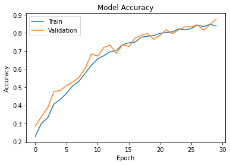

```python
plt.plot(history.history['accuracy'])
plt.plot(history.history['val_accuracy'])
plt.title('Model Accuracy')
plt.ylabel('Accuracy')
plt.xlabel('Epoch')
plt.legend(['Train', 'Validation'], loc='upper left')
plt.show()
```

```python
accuracy = model.evaluate(X_test_normalized, y_test_encoded, verbose=2)
```

```
15/15 - 2s - loss: 0.4789 - accuracy: 0.8758 - 2s/epoch - 150ms/step
```

We can observe that our accuracy has improved compared to our previous model.

```python
# Here we would get the output as probablities for each category
y_pred=model.predict(X_test_normalized)
```

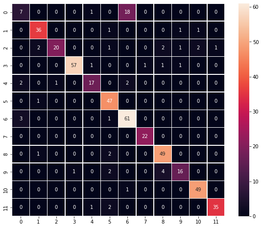

```python
# Obtaining the categorical values from y_test_encoded and y_pred
y_pred_arg=np.argmax(y_pred,axis=1)
y_test_arg=np.argmax(y_test_encoded,axis=1)

# Plotting the Confusion Matrix using confusion matrix() function which is also predefined tensorflow module
confusion_matrix = tf.math.confusion_matrix(y_test_arg,y_pred_arg)
f, ax = plt.subplots(figsize=(10, 8))
sns.heatmap(
    confusion_matrix,
    annot=True,
    linewidths=.4,
    fmt="d",
    square=True,
    ax=ax
)
plt.show()
```

- We can observe that this model has outperformed our previous model.

## Transfer Learning using VGG16

Let's try again, but this time, we will be using the idea of Transfer Learning. We will be loading a pre-built architecture - VGG16, which was trained on the ImageNet dataset and is the runner-up in the ImageNet competition in 2014.

For training VGG16, we will directly use the convolutional and pooling layers and freeze their weights i.e. no training will be done on them. For classification, we will replace the existing fully-connected layers with FC layers created specifically for our problem.

```python
from tensorflow.keras.models import Model
from keras.applications.vgg16 import VGG16

vgg_model = VGG16(weights='imagenet', include_top = False, input_shape = (256,256,3))
vgg_model.summary()
```

[output not shown]

```python
# Making all the layers of the VGG model non-trainable. i.e. freezing them
for layer in vgg_model.layers:
    layer.trainable = False
```

```python
new_model = Sequential()

# Adding the convolutional part of the VGG16 model from above
new_model.add(vgg_model)

# Flattening the output of the VGG16 model because it is from a convolutional layer
new_model.add(Flatten())

# Adding a dense output layer
new_model.add(Dense(32, activation='relu'))
new_model.add(Dropout(0.2))
new_model.add(Dense(16, activation='relu'))
new_model.add(Dense(12, activation='softmax'))
opt=Adam()
# Compile model
new_model.compile(optimizer=opt, loss='categorical_crossentropy', metrics=['accuracy'])

# Generating the summary of the model
new_model.summary()
```

[output not shown]

```python
# Epochs
epochs = 25
# Batch size
batch_size = 64

history_vgg16 = new_model.fit(train_datagen.flow(X_train_normalized,y_train_encoded,
                                       batch_size=batch_size,
                                       seed=42,
                                       shuffle=False),
                    epochs=epochs,
                    steps_per_epoch=X_train_normalized.shape[0] // batch_size,
                    validation_data=(X_test_normalized,y_test_encoded),
                    verbose=1)
```

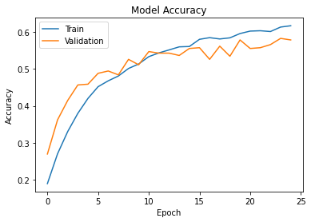

```python
plt.plot(history_vgg16.history['accuracy'])
plt.plot(history_vgg16.history['val_accuracy'])
plt.title('Model Accuracy')
plt.ylabel('Accuracy')
plt.xlabel('Epoch')
plt.legend(['Train', 'Validation'], loc='upper left')
plt.show()
```

```python
accuracy = new_model.evaluate(X_test_normalized, y_test_encoded, verbose=2)
```

```
15/15 - 1s - loss: 1.1593 - accuracy: 0.5789 - 644ms/epoch - 43ms/step
```

```python
# Here we would get the output as probablities for each category
y_pred=new_model.predict(X_test_normalized)
```

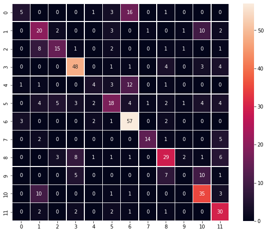

```python
# Obtaining the categorical values from y_test_encoded and y_pred
y_pred_arg=np.argmax(y_pred,axis=1)
y_test_arg=np.argmax(y_test_encoded,axis=1)

# Plotting the Confusion Matrix using confusion matrix() function which is also predefined tensorflow module
confusion_matrix = tf.math.confusion_matrix(y_test_arg,y_pred_arg)
f, ax = plt.subplots(figsize=(10, 8))
sns.heatmap(
    confusion_matrix,
    annot=True,
    linewidths=.4,
    fmt="d",
    square=True,
    ax=ax
)
plt.show()
```

## Visualizing the prediction:

[figure not shown]

```
Predicted Label ['Small-flowered Cranesbill']
True Label Small-flowered Cranesbill
```

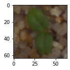

```
Predicted Label ['Cleavers']
True Label Cleavers
```

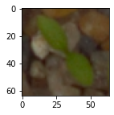

```
Predicted Label ['Common Chickweed']
True Label Common Chickweed
```

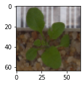

```
Predicted Label ['Shepherds Purse']
True Label Shepherds Purse
```

```python
# Visualizing the predicted and correct label of images from test data
plt.figure(figsize=(2,2))
plt.imshow(X_test[2])
plt.show()
# reshaping the input image as we are only trying to predict using a single image
print('Predicted Label', enc.inverse_transform(model.predict((X_test_normalized[2].reshape(1,64,64,3)))))
# using inverse_transform() to get the output label from the output vector
print('True Label', enc.inverse_transform(y_test_encoded)[2])

plt.figure(figsize=(2,2))
plt.imshow(X_test[33])
plt.show()
# reshaping the input image as we are only trying to predict using a single image
print('Predicted Label', enc.inverse_transform(model.predict((X_test_normalized[33].reshape(1,64,64,3)))))
# using inverse_transform() to get the output label from the output vector
print('True Label', enc.inverse_transform(y_test_encoded)[33])

plt.figure(figsize=(2,2))
plt.imshow(X_test[59],)
plt.show()
# reshaping the input image as we are only trying to predict using a single image
print('Predicted Label', enc.inverse_transform(model.predict((X_test_normalized[59].reshape(1,64,64,3)))))
# using inverse_transform() to get the output label from the output vector
print('True Label', enc.inverse_transform(y_test_encoded)[59])

plt.figure(figsize=(2,2))
plt.imshow(X_test[36])
plt.show()
# reshaping the input image as we are only trying to predict using a single image
print('Predicted Label', enc.inverse_transform(model.predict((X_test_normalized[36].reshape(1,64,64,3)))))
# using inverse_transform() to get the output label from the output vector
print('True Label', enc.inverse_transform(y_test_encoded)[36])
```

*Observations:*

- Out of four above predictions we got all 4 predictions right.

## Conclusion

```python
pd.DataFrame({'Models':['Base CNN Model','CNN Model with Data Augmentation','CNN Model with Data Augmentation - Diff parameter','Transfer Learning Model'],'Train Accuracy':['52%','71%','84%','62%'],'Test Accuracy':['63%','72%','87%','58%']})
```

|  | Models | Train Accuracy | Test Accuracy |
| --- | --- | --- | --- |
| 0 | Base CNN Model | 52% | 63% |
| 1 | CNN Model with Data Augmentation | 71% | 72% |
| 2 | CNN Model with Data Augmentation - Diff parameter | 84% | 87% |
| 3 | Transfer Learning Model | 62% | 58% |

## Scope of Improvement

- These models can be further improved by training with different filter sizes and different number of filters.
- These models can also be trained on the original image_size i.e 128 x 128 rather than being reduced to 64 and increased to 256.
- Data Augmentation can be performed more and dropout_rate can be changed to improve the model performance.
- Other Transfer Learning architectures can also be used to train the CNN model and these models can be used for classification.